# NMDS Reference Bugs- An example dataset

18 May, 2021

R version 4.0.3 (2020-10-10) – "Bunny-Wunnies Freak Out

Packages used for NMDS: vegan (version 2.5-7)

## Methods

The document serves as an example of analyses that will be conducted to identify natural variations in benthic communities across Virginia. These NMDS will support the Genus level IBI development process. An analysis will be conducted with the full reference dataset at a later time.

The dataset used is a subset of reference stations collected in the Roanoke River basin in BRRO. If stations appeared in the dataset more than 4 times, then the most recent 4 samples were used and the rest removed. Taxa that occurred in the dataset < 5% of the time were removed. The data was log10 +1 transformed. Environmental factors were compiled for each station and used to plot over the NMDS to show environmental variation associated with the community matrix. The envfit function in Vegan was used to plot the continuous environmental variables.

The first step was to read in the reference site bug taxa list and environmental factors dataset for each station. Join the environmental dataset with the bug dataset to account for multiple observations of each station and collection date and time.

Check to make sure the bug and environmental join was successful:

Number of rows in Community Matrix: 51

Number or rows in Environmental Matrix: 51

The data was log10+1 transformed. Rare taxa were removed in excel.

## Run NMDS for reference communities

```
## *** Solution reached
```

```
##
## Call:
## metaMDS(comm = BugNMS[, 1:87], k = 3)
##
## global Multidimensional Scaling using monoMDS
##
## Data:     BugNMS[, 1:87]
## Distance: bray
##
## Dimensions: 3
## Stress:     0.1411591
## Stress type 1, weak ties
## Two convergent solutions found after 20 tries
## Scaling: centring, PC rotation, halfchange scaling
## Species: expanded scores based on 'BugNMS[, 1:87]'
```

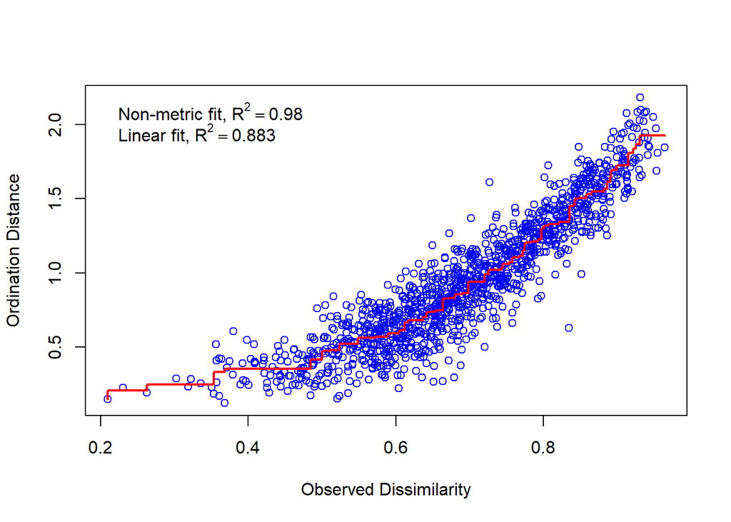

# Plot with Station IDs

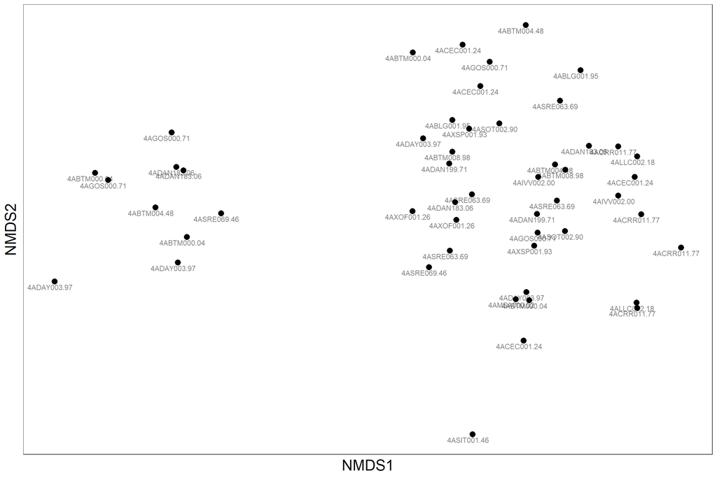

# Plot with Axis 3

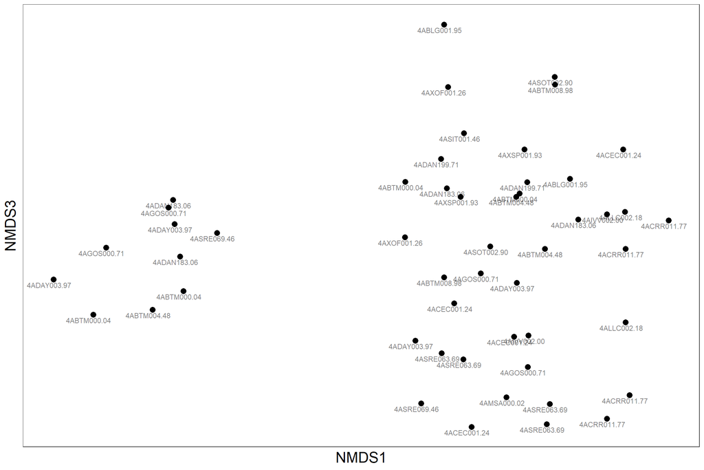

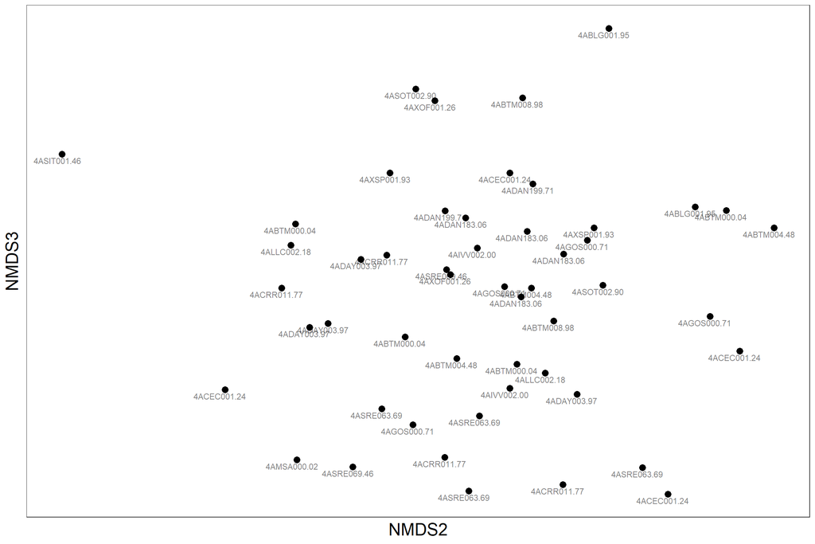

# Run NMS with categorical environmental variables

## Season

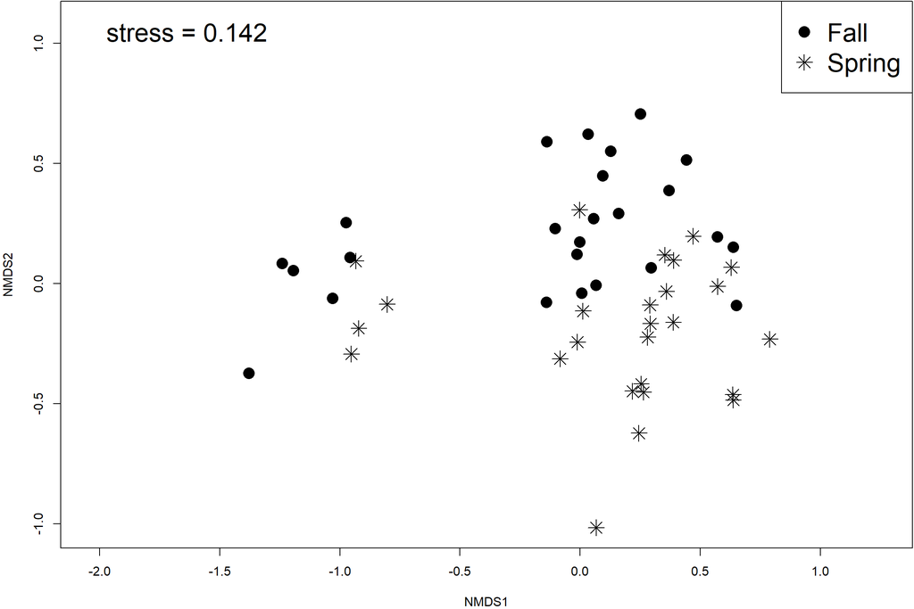

```
##
## Call:
## mrpp(dat = BugNMS[, 1:87], grouping = Season, distance = "bray")
##
## Dissimilarity index: bray
## Weights for groups:  n
##
## Class means and counts:
##
##       Fall   Spring
## delta 0.6708 0.6733
## n     25     26
##
## Chance corrected within-group agreement A: 0.0284
## Based on observed delta 0.6721 and expected delta 0.6917
##
## Significance of delta: 0.001
## Permutation: free
## Number of permutations: 999
```

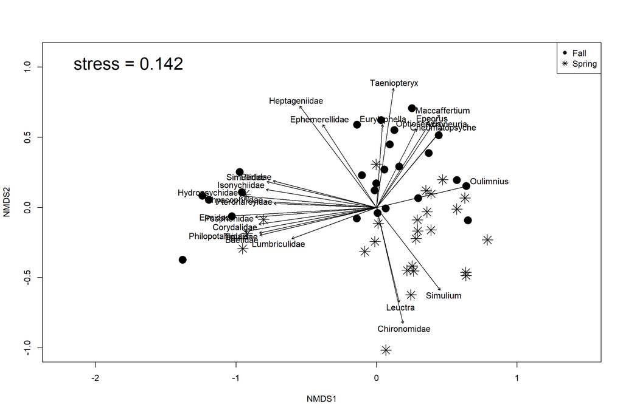

```
## $arrows
##                              NMDS1       NMDS2
## Acroneuria              0.63975592  0.76857814
## Allocapnia              0.15272139  0.98826928
## Amphinemura             0.94238881 -0.33451955
## Anchytarsus             0.41874625 -0.90810329
## Ancylidae               0.80283271  0.59620437
## Antocha                 0.30308255 -0.95296430
## Baetidae               -0.97287163 -0.23134562
## Baetis                  0.73125214 -0.68210726
## Blepharicera            0.58744888 -0.80926128
## Cambaridae             -0.95984200  0.28054113
## Capniidae              -0.45815241  0.88887365
## Cheumatopsyche          0.64281344  0.76602277
## Chimarra                0.68320394  0.73022762
## Chironomidae            0.22129047 -0.97520794
## Chloroperlidae         -0.94664050  0.32229143
## Cinygmula               0.88159550  0.47200570
## Clinocera               0.26749181 -0.96356013
## Corydalidae            -0.99015040 -0.14000778
## Dicranota               0.54551488  0.83810114
## Diplectrona             0.50650059  0.86223961
## Diploperla              0.62184609  0.78313948
## Dolophilodes            0.99688227 -0.07890338
## Drunella                0.50819893 -0.86123971
## Ectopria                0.36784790  0.92988597
## Elmidae                -0.99824063 -0.05929286
## Epeorus                 0.53102112  0.84735858
## Ephemerella             0.98806538 -0.15403508
## Ephemerellidae         -0.54478067  0.83857857
## Eurylophella            0.07140299  0.99744755
## Glossosoma              0.99030328 -0.13892233
## Gomphidae              -0.03572543  0.99936164
## Haploperla              0.74333798 -0.66891602
## Hemerodromia            0.63302938 -0.77412777
## Heptageniidae          -0.60331531  0.79750275
## Heterocloeon            0.99627906 -0.08618602
## Hexatoma                0.99503263 -0.09954934
## Hydracarina            -0.01894583  0.99982051
## Hydropsyche             0.50116492  0.86535179
```

[output cut: 177 more lines]

```
## Permutation Design:
##
## Blocks:
##   Defined by: none
##
## Plots:
##   Defined by: none
##
## Within Plots:
##   Permutation type: free
##
## Permutation details:
##   Number of permutations: 999
##   Max. number of permutations allowed: 9999
##   Evaluate all permutations?: No.  Activation limit: 5040
```

## Ecoregion

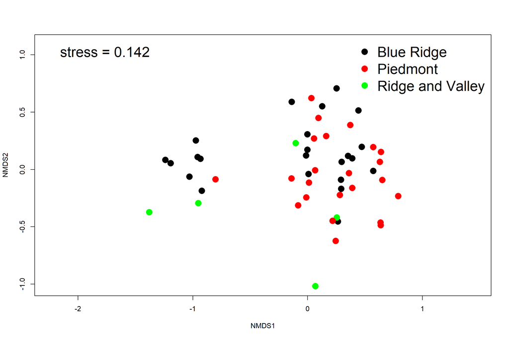

```
##
## Call:
## mrpp(dat = BugNMS[, 1:87], grouping = EPA_ECO_US_L3NAME, distance = "bray")
##
## Dissimilarity index: bray
## Weights for groups:  n
##
## Class means and counts:
##
##       Blue Ridge Piedmont Ridge and Valley
## delta 0.6751     0.6506   0.7479
## n     23         23       5
##
## Chance corrected within-group agreement A: 0.02969
## Based on observed delta 0.6712 and expected delta 0.6917
##
## Significance of delta: 0.004
## Permutation: free
## Number of permutations: 999
```

## Basin

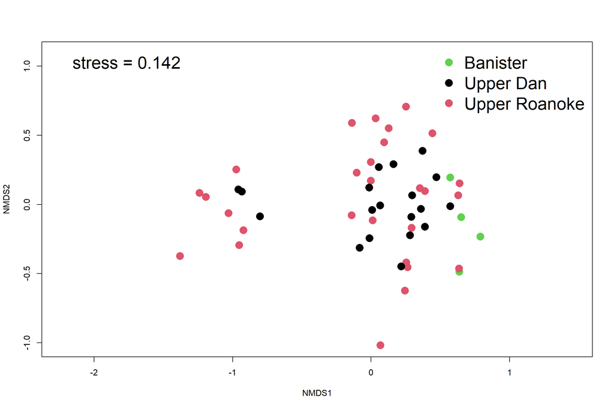

```
##
## Call:
## mrpp(dat = BugNMS[, 1:87], grouping = BASINS_HUC_8_NAME, distance = "bray")
##
## Dissimilarity index: bray
## Weights for groups:  n
##
## Class means and counts:
##
##       Banister Upper Dan Upper Roanoke
## delta 0.5518   0.6354    0.7142
## n     4        19        28
##
## Chance corrected within-group agreement A: 0.02835
## Based on observed delta 0.6721 and expected delta 0.6917
##
## Significance of delta: 0.007
## Permutation: free
## Number of permutations: 999
```

## Admin Region

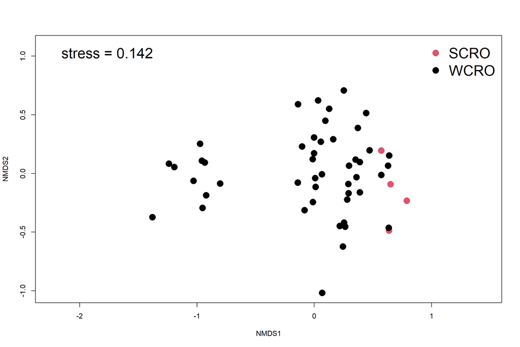

```
##
## Call:
## mrpp(dat = BugNMS[, 1:87], grouping = Admin_Region, distance = "bray")
##
## Dissimilarity index: bray
## Weights for groups:  n
##
## Class means and counts:
##
##       SCRO   WCRO
## delta 0.5518 0.6885
## n     4      47
##
## Chance corrected within-group agreement A: 0.02011
## Based on observed delta 0.6778 and expected delta 0.6917
##
## Significance of delta: 0.011
## Permutation: free
## Number of permutations: 999
```

## Sample Method

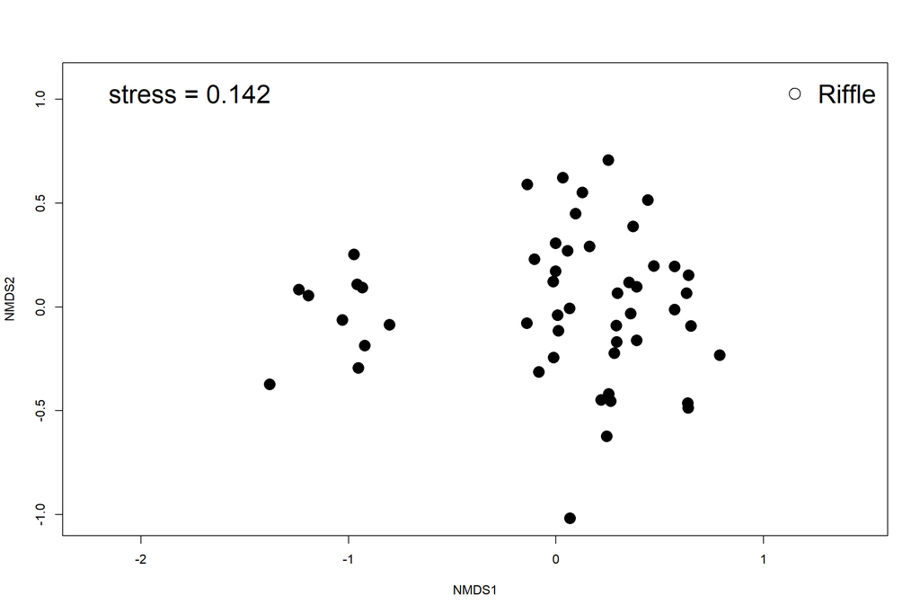

```
##
## Call:
## mrpp(dat = BugNMS[, 1:87], grouping = Gradient, distance = "bray")
##
## Dissimilarity index: bray
## Weights for groups:  n
##
## Class means and counts:
##
##       Riffle
## delta 0.6917
## n     51
##
## Chance corrected within-group agreement A:     0
## Based on observed delta 0.6917 and expected delta 0.6917
##
## Significance of delta: 1
## Permutation: free
## Number of permutations: 999
```

## BioRegion

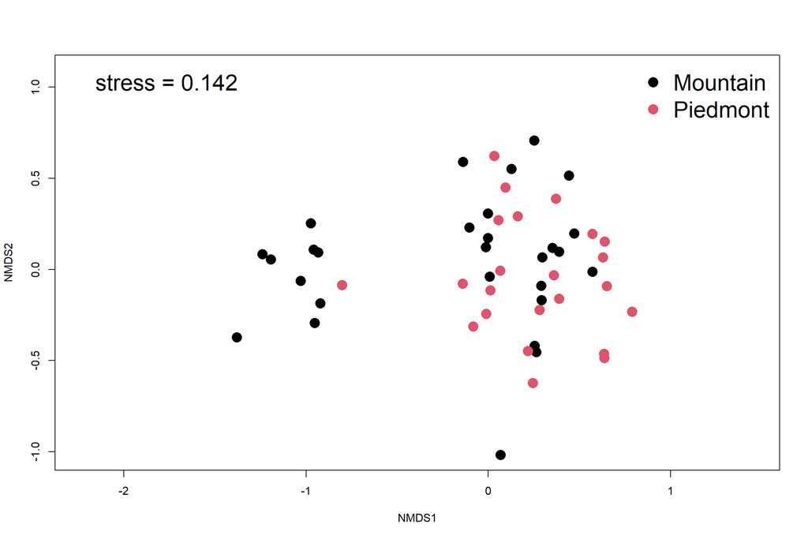

```
##
## Call:
## mrpp(dat = BugNMS[, 1:87], grouping = BioRegion, distance = "bray")
##
## Dissimilarity index: bray
## Weights for groups:  n
##
## Class means and counts:
##
##       Mountain Piedmont
## delta 0.6961   0.6506
## n     28       23
##
## Chance corrected within-group agreement A: 0.02332
## Based on observed delta 0.6756 and expected delta 0.6917
##
## Significance of delta: 0.002
## Permutation: free
## Number of permutations: 999
```

## BioRegion and Season

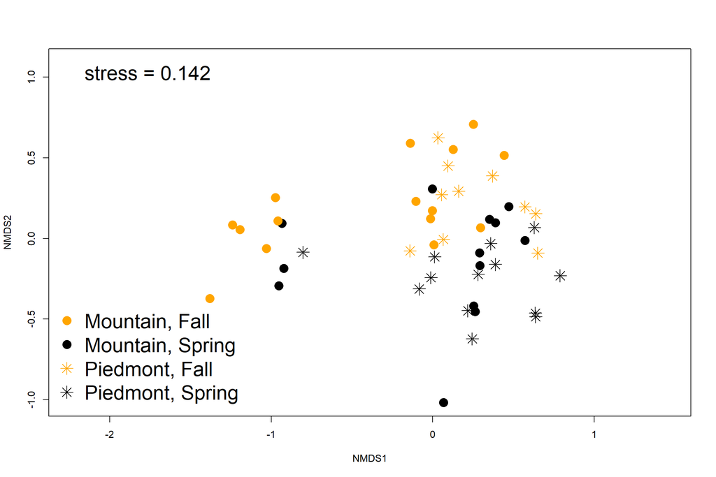

## Stream Order

[figure not shown]

```
##
## Call:
## mrpp(dat = BugNMS[, 1:87], grouping = WQM_STA_STRAHER_ORDER,      distance = "bray")
##
## Dissimilarity index: bray
## Weights for groups:  n
##
## Class means and counts:
##
##       0      1      2      3      4
## delta 0.7193 0.6131 0.6297 0.6818 0.6561
## n     4      7      12     26     2
##
## Chance corrected within-group agreement A: 0.04289
## Based on observed delta 0.662 and expected delta 0.6917
##
## Significance of delta: 0.004
## Permutation: free
## Number of permutations: 999
```

## Water Quality Standard Class

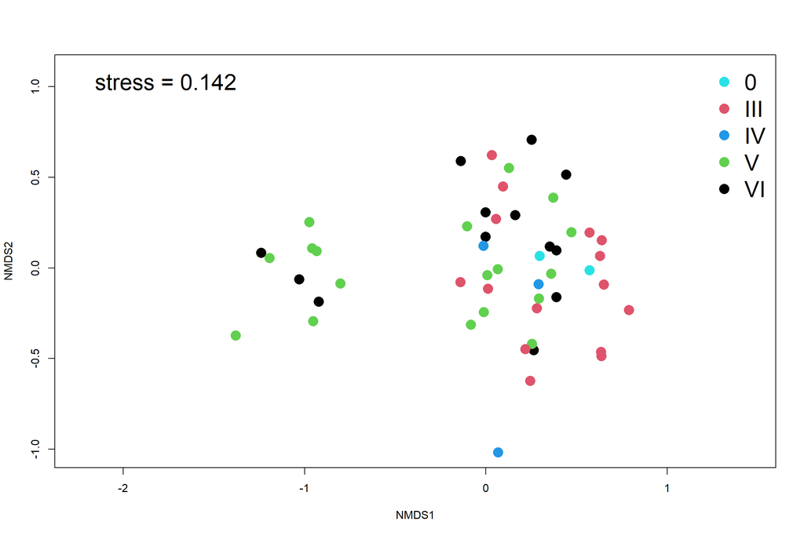

```
##
## Call:
## mrpp(dat = BugNMS[, 1:87], grouping = WQS_CLASS, distance = "bray")
##
## Dissimilarity index: bray
## Weights for groups:  n
##
## Class means and counts:
##
##       0      III    IV     V      VI
## delta 0.5204 0.6396 0.6462 0.6752 0.675
## n     2      15     3      18     13
##
## Chance corrected within-group agreement A: 0.05033
## Based on observed delta 0.6569 and expected delta 0.6917
##
## Significance of delta: 0.001
## Permutation: free
## Number of permutations: 999
```

## Natural Trout Water WQS?

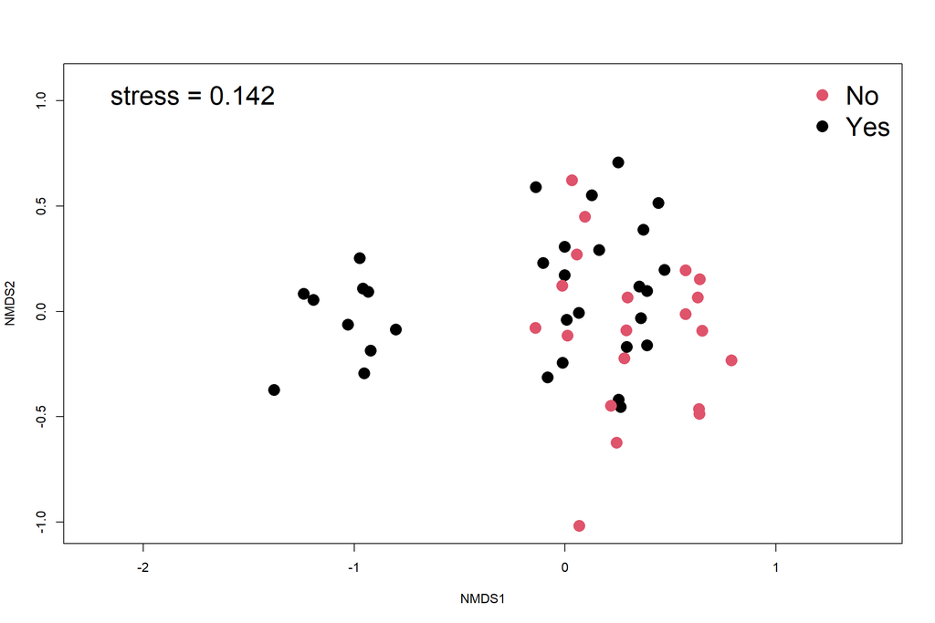

```
##
## Call:
## mrpp(dat = BugNMS[, 1:87], grouping = WQS_TROUT, distance = "bray")
##
## Dissimilarity index: bray
## Weights for groups:  n
##
## Class means and counts:
##
##       No     Yes
## delta 0.6415 0.6871
## n     20     31
##
## Chance corrected within-group agreement A: 0.03252
## Based on observed delta 0.6692 and expected delta 0.6917
##
## Significance of delta: 0.001
## Permutation: free
## Number of permutations: 999
```

# Continuous Environmental Variables

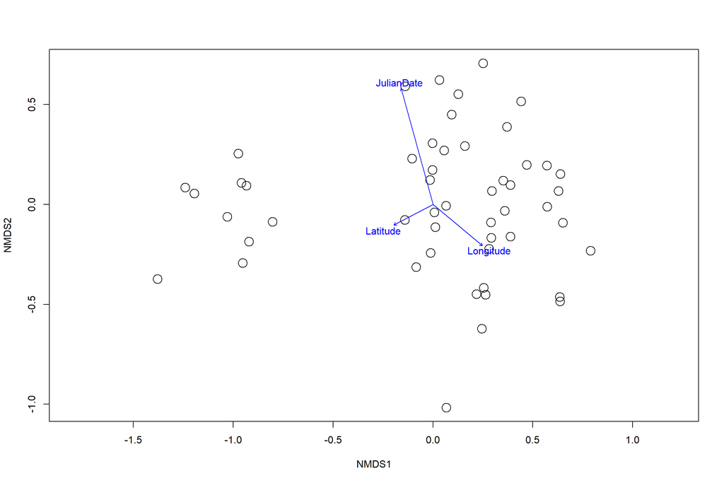

```
## $vectors
##               NMDS1    NMDS2     r2 Pr(>r)
## JulianDate -0.26464  0.96435 0.4286  0.001 ***
## Latitude   -0.88414 -0.46723 0.0576  0.246
## Longitude   0.76784 -0.64064 0.1224  0.039 *
## ---
## Signif. codes:  0 '***' 0.001 '**' 0.01 '*' 0.05 '.' 0.1 ' ' 1
## Permutation: free
## Number of permutations: 999
##
## $factors
## NULL
##
## $na.action
## function (object, ...)
## UseMethod("na.action")
## <bytecode: 0x0000000013657898>
## <environment: namespace:stats>
```